# 6_8_CV_Practice2_Solved

# Exercise

For this exercise use the quarterly number of arrivals to Australia from New Zealand, 1981 Q1 – 2012 Q3, from data set `aus_arrivals`.

```r
# Filter data:
nzarrivals <- aus_arrivals %>% filter(Origin == "NZ")
nzarrivals
```

```
# A tsibble: 127 x 3 [1Q]
# Key:       Origin [1]
   Quarter Origin Arrivals
     <qtr> <chr>     <int>
 1 1981 Q1 NZ        49140
 2 1981 Q2 NZ        87467
 3 1981 Q3 NZ        85841
 4 1981 Q4 NZ        61882
 5 1982 Q1 NZ        42045
 6 1982 Q2 NZ        63081
 7 1982 Q3 NZ        73275
 8 1982 Q4 NZ        54808
 9 1983 Q1 NZ        41030
10 1983 Q2 NZ        56155
# … with 117 more rows
```

## a. Make a time-plot of your data. Ensure that the grid indicates at least the end of each seasonal period.**

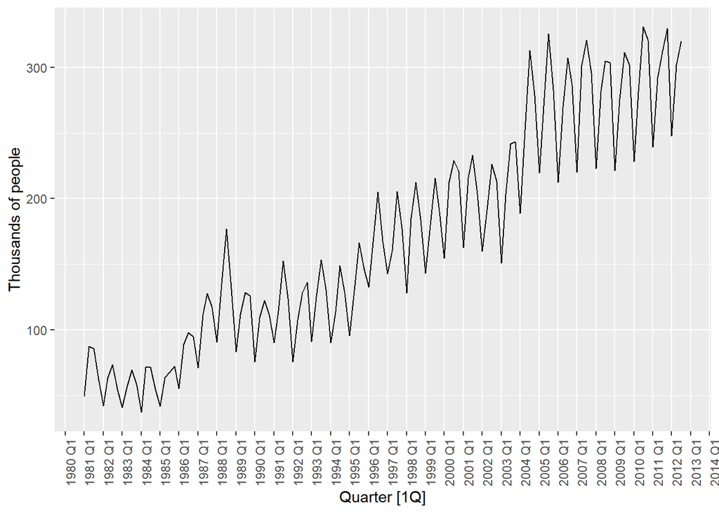

```r
nzarrivals %>%
  autoplot(Arrivals / 1e3) + labs(y = "Thousands of people") +

  # Adjust the x-grid
  scale_x_yearquarter(date_breaks = "1 year",
                      date_minor_breaks = "1 year") +

  # Flip x-labels by 90 degrees
  theme(axis.text.x = element_text(angle = 90))
```

## **b. Create a training set that withholds the last two years of available data for test purposes.**

```r
test_years = 2

train <- nzarrivals %>%
  filter(Quarter <= max(Quarter) - test_years*4)

train
```

```
# A tsibble: 119 x 3 [1Q]
# Key:       Origin [1]
   Quarter Origin Arrivals
     <qtr> <chr>     <int>
 1 1981 Q1 NZ        49140
 2 1981 Q2 NZ        87467
 3 1981 Q3 NZ        85841
 4 1981 Q4 NZ        61882
 5 1982 Q1 NZ        42045
 6 1982 Q2 NZ        63081
 7 1982 Q3 NZ        73275
 8 1982 Q4 NZ        54808
 9 1983 Q1 NZ        41030
10 1983 Q2 NZ        56155
# … with 109 more rows
```

## **c. Fit the following models to your training dataset and create 8-step ahead forecasts:**

- A seasonal naïve method
- An additive STL decomposition separating the seasonally-adjusted component and the seasonal component using `decomposition_model()`. **Is a transformation necessary**?

First, from the time-plot it is clear that the series is multiplicative, at least to some extent (variance of seasonal component proportional to the level of the series). For the `decomposition_model()` using an STL decomposition, we will need to make the data additive beforehand because STL decomposition is only applicable to additive data.

Let us therefore explore the value lambda-value for an optimal box-cox transformation:

```r
lambda <- nzarrivals %>%
  features(Arrivals/1e3, features = guerrero) %>%
  pull(lambda_guerrero)

lambda
```

```
[1] 0.3320207
```

Let us now check what this transformation attains by depicting the transformed data in a time-plot:

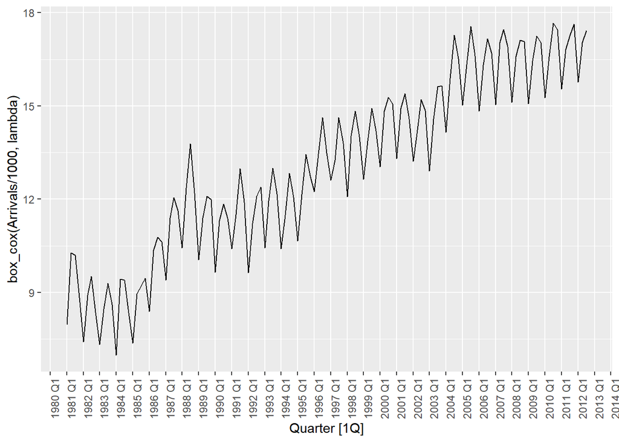

```r
nzarrivals %>%
  autoplot(box_cox(Arrivals/1e3, lambda)) +

  # Adjust the x-grid
  scale_x_yearquarter(date_breaks = "1 year",
                      date_minor_breaks = "1 year") +

  # Flip x-labels by 90 degrees
  theme(axis.text.x = element_text(angle = 90))
```

Indeed the box-cox transformation has made the scheme additive, perhaps with the exception of the year 1988. We will use this transformation.

Let us start by recalling the name of the output components of an STL decomposition:

```r
nzarrivals %>%
  model(
    STL(box_cox(Arrivals/1e3, lambda))
  ) %>%
  components() %>%
  select(Quarter, `box_cox(Arrivals/1000, lambda)`, trend, season_year, remainder, season_adjust)
```

```
# A tsibble: 127 x 6 [1Q]
   Quarter `box_cox(Arrivals/1000, lambda)` trend season_year remainder season…¹
     <qtr>                            <dbl> <dbl>       <dbl>     <dbl>    <dbl>
 1 1981 Q1                             7.96  9.63     -1.35     -0.315      9.31
 2 1981 Q2                            10.3   9.43      0.456     0.395      9.82
 3 1981 Q3                            10.2   9.23      0.845     0.123      9.35
 4 1981 Q4                             8.84  9.00      0.0500   -0.209      8.79
 5 1982 Q1                             7.41  8.74     -1.35      0.0151     8.76
 6 1982 Q2                             8.91  8.61      0.448    -0.146      8.46
 7 1982 Q3                             9.52  8.54      0.843     0.142      8.68
 8 1982 Q4                             8.37  8.48      0.0592   -0.174      8.31
 9 1983 Q1                             7.33  8.39     -1.35      0.280      8.67
10 1983 Q2                             8.46  8.38      0.440    -0.359      8.02
# … with 117 more rows, and abbreviated variable name ¹season_adjust
```

When using `decomposition_model()` we need to specify a model for `season_adjust` (the seasonally adjusted component) and a model for `season_year` (the seasonal component. In this case we have yearly seasonality).

We will now fit an additive decomposition model using `decomposition_model()` as well as a seasonal naive component using `SNAIVE()`

```r
fit <- train %>%
      model(
        # Model 1: additive decomposition based on STL
        # season_adjust and season_year modelled separately
        decomp = decomposition_model(
                    # Specify decomposition scheme to be used
                    STL(box_cox(Arrivals/1e3, lambda)),
                    # Specify model for the seasonally adjusted component
                    RW(season_adjust ~ drift()),
                    # Specify model for the seasonal component (unnecessary since SNAIVE is default)
                    SNAIVE(season_year)
                    ),

        # Model 2: seasonal naïve component
        seas_naive = SNAIVE(Arrivals)

        )

fit
```

```
# A mable: 1 x 3
# Key:     Origin [1]
  Origin                    decomp seas_naive
  <chr>                    <model>    <model>
1 NZ     <STL decomposition model>   <SNAIVE>
```

We can see that we get an output of a `mable` with 1 row (one time-series being fitted) and 2 columns (two models used). Let us now produce forecasts with these models. Since we left out two years in the test data (8 quarters) we will generate 8-step forecast:

```r
fc <- fit %>% forecast(h=8)
fc
```

```
# A fable: 16 x 5 [1Q]
# Key:     Origin, .model [2]
   Origin .model     Quarter           Arrivals   .mean
   <chr>  <chr>        <qtr>             <dist>   <dbl>
 1 NZ     decomp     2010 Q4     t(N(17, 0.14)) 311247.
 2 NZ     decomp     2011 Q1     t(N(16, 0.27)) 238219.
 3 NZ     decomp     2011 Q2     t(N(17, 0.41)) 303048.
 4 NZ     decomp     2011 Q3     t(N(18, 0.55)) 344465.
 5 NZ     decomp     2011 Q4      t(N(17, 0.7)) 324401.
 6 NZ     decomp     2012 Q1     t(N(16, 0.85)) 249350.
 7 NZ     decomp     2012 Q2     t(N(17, 0.99)) 316015.
 8 NZ     decomp     2012 Q3      t(N(18, 1.1)) 358541.
 9 NZ     seas_naive 2010 Q4  N(3e+05, 3.7e+08) 301983
10 NZ     seas_naive 2011 Q1 N(228162, 3.7e+08) 228162
11 NZ     seas_naive 2011 Q2 N(281791, 3.7e+08) 281791
12 NZ     seas_naive 2011 Q3 N(330812, 3.7e+08) 330812
13 NZ     seas_naive 2011 Q4  N(3e+05, 7.5e+08) 301983
14 NZ     seas_naive 2012 Q1 N(228162, 7.5e+08) 228162
15 NZ     seas_naive 2012 Q2 N(281791, 7.5e+08) 281791
16 NZ     seas_naive 2012 Q3 N(330812, 7.5e+08) 330812
```

As expected we obtain 16 rows, since we are producing 8 forecasts per model (2 models).

## **d. Which model performs better with this particular train-test split?**

We now wish to produce summary error metrics for the two models we fitted. We can do this with `accuracy()`.

- **First argument:** the `fable` or forecasts table
- **Second argument:** the dataset containing both the training and the test dataset

```r
accuracy(fc, nzarrivals) %>% select(.model, RMSE, MAE, MAPE, MASE, RMSSE)
```

```
# A tibble: 2 × 6
  .model       RMSE    MAE  MAPE  MASE RMSSE
  <chr>       <dbl>  <dbl> <dbl> <dbl> <dbl>
1 decomp     19346. 14166.  4.56 0.952 1.00
2 seas_naive 18051. 17156.  5.80 1.15  0.933
```

Plase note that **the metrics above are averaged over all the forecast horizons**. If we wished to compute the metrics for each combination of `.model` and `h`, we would first need to create an `h` column on the forecasts table as follows:

```r
fc <- fc %>%
        group_by(.model) %>%
        mutate(h = row_number()) %>%
        ungroup() %>%
        as_fable(response = "Arrivals", distribution = Arrivals) %>%
        select(h, everything())

fc
```

```
# A fable: 16 x 6 [1Q]
# Key:     Origin, .model [2]
       h Origin .model     Quarter           Arrivals   .mean
   <int> <chr>  <chr>        <qtr>             <dist>   <dbl>
 1     1 NZ     decomp     2010 Q4     t(N(17, 0.14)) 311247.
 2     2 NZ     decomp     2011 Q1     t(N(16, 0.27)) 238219.
 3     3 NZ     decomp     2011 Q2     t(N(17, 0.41)) 303048.
 4     4 NZ     decomp     2011 Q3     t(N(18, 0.55)) 344465.
 5     5 NZ     decomp     2011 Q4      t(N(17, 0.7)) 324401.
 6     6 NZ     decomp     2012 Q1     t(N(16, 0.85)) 249350.
 7     7 NZ     decomp     2012 Q2     t(N(17, 0.99)) 316015.
 8     8 NZ     decomp     2012 Q3      t(N(18, 1.1)) 358541.
 9     1 NZ     seas_naive 2010 Q4  N(3e+05, 3.7e+08) 301983
10     2 NZ     seas_naive 2011 Q1 N(228162, 3.7e+08) 228162
11     3 NZ     seas_naive 2011 Q2 N(281791, 3.7e+08) 281791
12     4 NZ     seas_naive 2011 Q3 N(330812, 3.7e+08) 330812
13     5 NZ     seas_naive 2011 Q4  N(3e+05, 7.5e+08) 301983
14     6 NZ     seas_naive 2012 Q1 N(228162, 7.5e+08) 228162
15     7 NZ     seas_naive 2012 Q2 N(281791, 7.5e+08) 281791
16     8 NZ     seas_naive 2012 Q3 N(330812, 7.5e+08) 330812
```

and now compute the accuracy metrics specifying that they need to be split by each combination of `h` and `.model`

```r
accuracy(fc, nzarrivals, by=c("h", ".model")) %>% select(h, .model, RMSE, MAE, MAPE, MASE, RMSSE)
```

[output not shown]

```
# A tibble: 16 × 7
       h .model       RMSE    MAE   MAPE   MASE  RMSSE
   <int> <chr>       <dbl>  <dbl>  <dbl>  <dbl>  <dbl>
 1     1 decomp      9650.  9650.  3.01  0.649  0.499
 2     1 seas_naive 18914  18914   5.89  1.27   0.977
 3     2 decomp       884.   884.  0.370 0.0593 0.0457
 4     2 seas_naive 10941  10941   4.58  0.734  0.565
 5     3 decomp     10976. 10976.  3.76  0.738  0.569
 6     3 seas_naive 10281  10281   3.52  0.691  0.533
 7     4 decomp     32471. 32471. 10.4   2.19   1.69
 8     4 seas_naive 18818  18818   6.03  1.27   0.978
 9     5 decomp      5069.  5069.  1.54  0.341  0.264
10     5 seas_naive 27487  27487   8.34  1.85   1.43
11     6 decomp      1440.  1440.  0.581 0.0972 0.0752
12     6 seas_naive 19748  19748   7.97  1.33   1.03
13     7 decomp     14135. 14135.  4.68  0.957  0.740
14     7 seas_naive 20089  20089   6.65  1.36   1.05
15     8 decomp     38701. 38701. 12.1   2.63   2.03
16     8 seas_naive 10972  10972   3.43  0.745  0.576
```

## **e. Perofrm cross-validation instead of using a single training-test set split. Do you come to the same conclusions?**

To perform cross-validation we need to use the function `stretch_tsibble()` to create multiple train-test datasets. Since we want a forecast horizont of 8 the minimum size of our training datasets must be 8. Therefore, we will set `.init = 8`

We will proceed in a step-by-step manner to understand in depth the output of each step, but all these steps could be joined together in a single pipe.

```r
nzarrivals_cv <- nzarrivals %>%
  stretch_tsibble(.init = 8, .step = 1)

# Number of training datasets created
nzarrivals_cv %>% pull(.id) %>% max
```

```
[1] 120
```

```r
# Check size of each training dataset
nzarrivals_cv %>%
  as_tibble() %>% # Cast to a tibble to be able to do away with time index
  group_by(.id) %>%
  summarize(
    size = n()
  )
```

```
# A tibble: 120 × 2
     .id  size
   <int> <int>
 1     1     8
 2     2     9
 3     3    10
 4     4    11
 5     5    12
 6     6    13
 7     7    14
 8     8    15
 9     9    16
10    10    17
# … with 110 more rows
```

We can see that 120 training datasets have been created, ranging in size from 8 to 127

Now we will proceed to fit out models to these datasets:

```r
fit_cv <- nzarrivals_cv %>%
      model(
        # Model 1: additive decomposition based on STL
        # season_adjust and season_year modelled separately
        decomp = decomposition_model(
                    # Specify decomposition scheme to be used
                    STL(box_cox(Arrivals/1e3, lambda)),
                    # Specify model for the seasonally adjusted component
                    RW(season_adjust ~ drift()),
                    # Specify model for the seasonal component (unnecessary since SNAIVE is default)
                    SNAIVE(season_year)
                    ),

        # Model 2: seasonal naïve component
        seas_naive = SNAIVE(Arrivals)

        )
fit_cv
```

```
# A mable: 120 x 4
# Key:     .id, Origin [120]
     .id Origin                    decomp seas_naive
   <int> <chr>                    <model>    <model>
 1     1 NZ                  <NULL model>   <SNAIVE>
 2     2 NZ     <STL decomposition model>   <SNAIVE>
 3     3 NZ     <STL decomposition model>   <SNAIVE>
 4     4 NZ     <STL decomposition model>   <SNAIVE>
 5     5 NZ     <STL decomposition model>   <SNAIVE>
 6     6 NZ     <STL decomposition model>   <SNAIVE>
 7     7 NZ     <STL decomposition model>   <SNAIVE>
 8     8 NZ     <STL decomposition model>   <SNAIVE>
 9     9 NZ     <STL decomposition model>   <SNAIVE>
10    10 NZ     <STL decomposition model>   <SNAIVE>
# … with 110 more rows
```

As expected we get a `mable` (model table) of 120 rows, each row corresponding to a training dataset. We have two different model columns (`decomp` and `seas_naive`) because we fitted two models to each of those trainig datasets.

We now move on and generate forecasts of a horizon of up to 8 for each of these models:

```r
fc_cv <- fit_cv %>% forecast(h=8)
fc_cv
```

```
# A fable: 1,920 x 6 [1Q]
# Key:     .id, Origin, .model [240]
     .id Origin .model     Quarter          Arrivals .mean
   <int> <chr>  <chr>        <qtr>            <dist> <dbl>
 1     1 NZ     decomp     1983 Q1             t(NA)    NA
 2     1 NZ     decomp     1983 Q2             t(NA)    NA
 3     1 NZ     decomp     1983 Q3             t(NA)    NA
 4     1 NZ     decomp     1983 Q4             t(NA)    NA
 5     1 NZ     decomp     1984 Q1             t(NA)    NA
 6     1 NZ     decomp     1984 Q2             t(NA)    NA
 7     1 NZ     decomp     1984 Q3             t(NA)    NA
 8     1 NZ     decomp     1984 Q4             t(NA)    NA
 9     1 NZ     seas_naive 1983 Q1 N(42045, 2.1e+08) 42045
10     1 NZ     seas_naive 1983 Q2 N(63081, 2.1e+08) 63081
# … with 1,910 more rows
```

The result is a `fable` (forecasts table) with 1920 rows, that is 120 (training datasets) * 8 (number of forecasts) * 2 (number of models).

```r
fc_cv <- fc_cv %>%
  group_by(.id, .model) %>%
  mutate(h = row_number()) %>%
  ungroup() %>%
  as_fable(response = "Arrivals", distribution = Arrivals)

fc_cv
```

```
# A fable: 1,920 x 7 [1Q]
# Key:     .id, Origin, .model [240]
     .id Origin .model     Quarter          Arrivals .mean     h
   <int> <chr>  <chr>        <qtr>            <dist> <dbl> <int>
 1     1 NZ     decomp     1983 Q1             t(NA)    NA     1
 2     1 NZ     decomp     1983 Q2             t(NA)    NA     2
 3     1 NZ     decomp     1983 Q3             t(NA)    NA     3
 4     1 NZ     decomp     1983 Q4             t(NA)    NA     4
 5     1 NZ     decomp     1984 Q1             t(NA)    NA     5
 6     1 NZ     decomp     1984 Q2             t(NA)    NA     6
 7     1 NZ     decomp     1984 Q3             t(NA)    NA     7
 8     1 NZ     decomp     1984 Q4             t(NA)    NA     8
 9     1 NZ     seas_naive 1983 Q1 N(42045, 2.1e+08) 42045     1
10     1 NZ     seas_naive 1983 Q2 N(63081, 2.1e+08) 63081     2
# … with 1,910 more rows
```

Now we will generate the cross validated accuracy metrics for each combination of model and forecast horizon:

```r
summary_cv <- fc_cv %>%
  accuracy(nzarrivals, by = c("h", ".model")) %>%
  select(h, .model, .type, MAE, RMSE, MAPE, MASE, RMSSE)
summary_cv
```

```
# A tibble: 16 × 8
       h .model     .type    MAE   RMSE  MAPE  MASE RMSSE
   <int> <chr>      <chr>  <dbl>  <dbl> <dbl> <dbl> <dbl>
 1     1 decomp     Test   9891. 12704.  6.50 0.674 0.669
 2     1 seas_naive Test  14738. 19112.  9.79 1.00  1.01
 3     2 decomp     Test  11217. 14456.  7.59 0.764 0.762
 4     2 seas_naive Test  14855. 19193.  9.85 1.01  1.01
 5     3 decomp     Test  13538. 17696.  8.94 0.923 0.932
 6     3 seas_naive Test  14922. 19264.  9.83 1.02  1.01
 7     4 decomp     Test  14662. 18986.  9.98 0.999 1.00
 8     4 seas_naive Test  15018. 19344.  9.87 1.02  1.02
 9     5 decomp     Test  18017. 22217. 11.7  1.23  1.17
10     5 seas_naive Test  21045. 28795. 12.9  1.43  1.52
11     6 decomp     Test  20145. 24602. 13.2  1.37  1.30
12     6 seas_naive Test  21186. 28917. 12.9  1.44  1.52
13     7 decomp     Test  20752. 26344. 13.5  1.41  1.39
14     7 seas_naive Test  21298. 29034. 12.9  1.45  1.53
15     8 decomp     Test  21843. 28140. 14.1  1.49  1.48
16     8 seas_naive Test  21471. 29163. 13.0  1.46  1.54
```

In this manner we could inspect which model is best to generate predictions for a particular forecast horizon. For a given metric, we could generate a graph comparing the different models we fitted as follows:

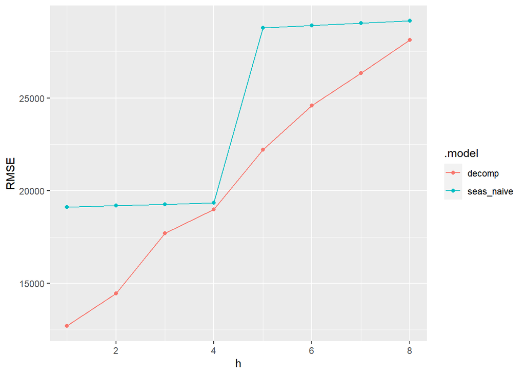

```r
summary_cv %>%
  ggplot(aes(x = h, y = RMSE, color = .model)) +
  geom_point() +
  geom_line()
```

We could even go beyond and create a single graph for each metric usng `facet_wrap`. For this, however, we would need to have a column detailing the metric corresponding to each value. That is, we need to make our data “longer” using `pivot_longer()`. You can see details on how to use this function on the notebook `2_2_tsibbles_import_timeplots_w_solutions`.

```r
summary_cv %>%
  pivot_longer(c(MAE, RMSE, MAPE, MASE, RMSSE), names_to = "metric", values_to = "value")
```

```
# A tibble: 80 × 5
       h .model     .type metric     value
   <int> <chr>      <chr> <chr>      <dbl>
 1     1 decomp     Test  MAE     9891.
 2     1 decomp     Test  RMSE   12704.
 3     1 decomp     Test  MAPE       6.50
 4     1 decomp     Test  MASE       0.674
 5     1 decomp     Test  RMSSE      0.669
 6     1 seas_naive Test  MAE    14738.
 7     1 seas_naive Test  RMSE   19112.
 8     1 seas_naive Test  MAPE       9.79
 9     1 seas_naive Test  MASE       1.00
10     1 seas_naive Test  RMSSE      1.01
# … with 70 more rows
```

You can see the above code puts the values for all the metrics in a single column and in exchange extends the number of rows. The column `metric` indicates to which metric each value belongs. This data structure enables us to use `facet_wrap()` as follows

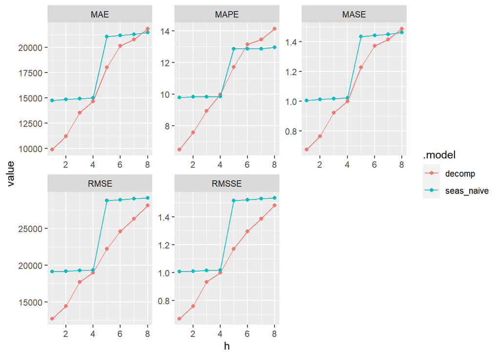

```r
summary_cv %>%
  pivot_longer(c(MAE, RMSE, MAPE, MASE, RMSSE), names_to = "metric", values_to = "value") %>%
  ggplot(aes(x = h, y = value, color = .model)) +
  geom_point() +
  geom_line() +
  facet_wrap(~ metric, nrow = 2, scales = "free")
```

We have set the argument `scale = "free"` so that the `y` scales of the graphs are independent from each other.

## Cross-validated results vs. single test-train split

Let us replicate the same graph, but this time with the forecasts we generated using a single train-test split (remember we stored this in the variable `fc`). As before the first thing we do is create a column to identify the forecast horizon:

```r
fc <- fc %>%
  group_by(.model) %>%
  mutate(h = row_number()) %>%
  ungroup() %>%
  as_fable(response = "Arrivals", distribution = Arrivals)

fc
```

```
# A fable: 16 x 6 [1Q]
# Key:     Origin, .model [2]
       h Origin .model     Quarter           Arrivals   .mean
   <int> <chr>  <chr>        <qtr>             <dist>   <dbl>
 1     1 NZ     decomp     2010 Q4     t(N(17, 0.14)) 311247.
 2     2 NZ     decomp     2011 Q1     t(N(16, 0.27)) 238219.
 3     3 NZ     decomp     2011 Q2     t(N(17, 0.41)) 303048.
 4     4 NZ     decomp     2011 Q3     t(N(18, 0.55)) 344465.
 5     5 NZ     decomp     2011 Q4      t(N(17, 0.7)) 324401.
 6     6 NZ     decomp     2012 Q1     t(N(16, 0.85)) 249350.
 7     7 NZ     decomp     2012 Q2     t(N(17, 0.99)) 316015.
 8     8 NZ     decomp     2012 Q3      t(N(18, 1.1)) 358541.
 9     1 NZ     seas_naive 2010 Q4  N(3e+05, 3.7e+08) 301983
10     2 NZ     seas_naive 2011 Q1 N(228162, 3.7e+08) 228162
11     3 NZ     seas_naive 2011 Q2 N(281791, 3.7e+08) 281791
12     4 NZ     seas_naive 2011 Q3 N(330812, 3.7e+08) 330812
13     5 NZ     seas_naive 2011 Q4  N(3e+05, 7.5e+08) 301983
14     6 NZ     seas_naive 2012 Q1 N(228162, 7.5e+08) 228162
15     7 NZ     seas_naive 2012 Q2 N(281791, 7.5e+08) 281791
16     8 NZ     seas_naive 2012 Q3 N(330812, 7.5e+08) 330812
```

We now proceed to apply the function `accuracy()` function grouping both by model and forecast horizon

```r
summary <- fc %>%
  accuracy(nzarrivals, by = c("h", ".model")) %>%
  select(h, .model, .type, MAE, RMSE, MAPE, MASE, RMSSE)
```

[output not shown]

```r
summary
```

```
# A tibble: 16 × 8
       h .model     .type    MAE   RMSE   MAPE   MASE  RMSSE
   <int> <chr>      <chr>  <dbl>  <dbl>  <dbl>  <dbl>  <dbl>
 1     1 decomp     Test   9650.  9650.  3.01  0.649  0.499
 2     1 seas_naive Test  18914  18914   5.89  1.27   0.977
 3     2 decomp     Test    884.   884.  0.370 0.0593 0.0457
 4     2 seas_naive Test  10941  10941   4.58  0.734  0.565
 5     3 decomp     Test  10976. 10976.  3.76  0.738  0.569
 6     3 seas_naive Test  10281  10281   3.52  0.691  0.533
 7     4 decomp     Test  32471. 32471. 10.4   2.19   1.69
 8     4 seas_naive Test  18818  18818   6.03  1.27   0.978
 9     5 decomp     Test   5069.  5069.  1.54  0.341  0.264
10     5 seas_naive Test  27487  27487   8.34  1.85   1.43
11     6 decomp     Test   1440.  1440.  0.581 0.0972 0.0752
12     6 seas_naive Test  19748  19748   7.97  1.33   1.03
13     7 decomp     Test  14135. 14135.  4.68  0.957  0.740
14     7 seas_naive Test  20089  20089   6.65  1.36   1.05
15     8 decomp     Test  38701. 38701. 12.1   2.63   2.03
16     8 seas_naive Test  10972  10972   3.43  0.745  0.576
```

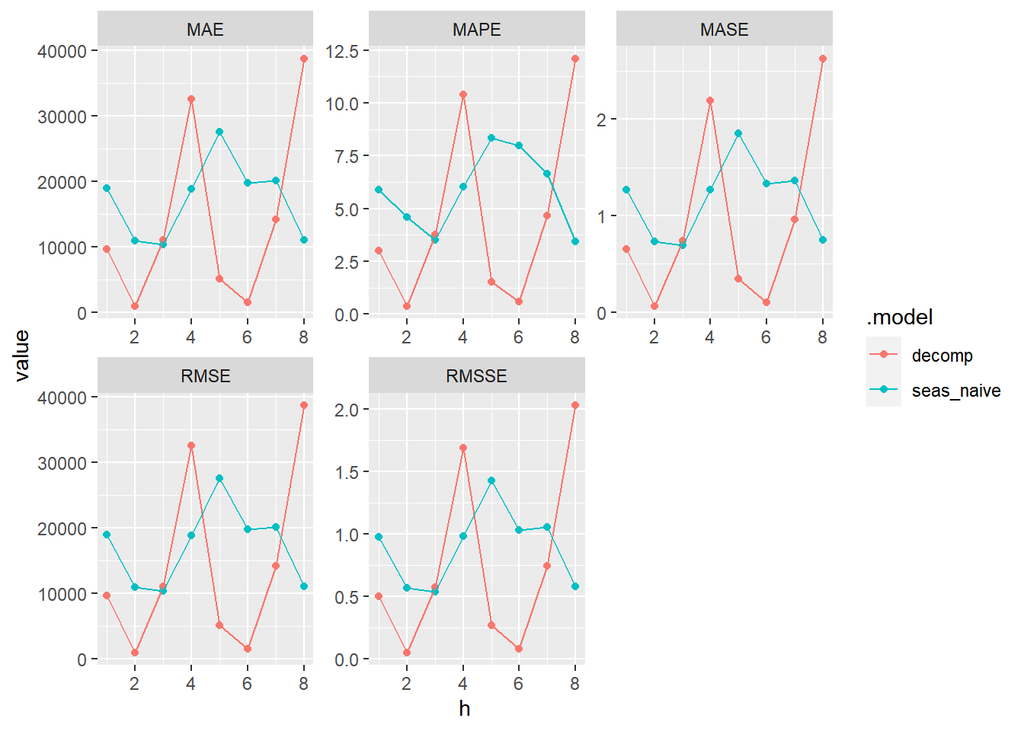

```r
summary %>%
  pivot_longer(c(MAE, RMSE, MAPE, MASE, RMSSE), names_to = "metric", values_to = "value") %>%
  ggplot(aes(x = h, y = value, color = .model)) +
  geom_point() +
  geom_line() +
  facet_wrap(~ metric, nrow = 2, scales = "free")
```

You can clearly see that using a single test-train split results in error metrics that are not reliable. It is only when we average them over multiple test-train sets that we start getting statistically robust results with which to judge the model.